# Synthetic disturbance–response series

Idealized climate driver & lagged response across a regime shift

nic (nic@cascadeclimate.org)

2026-07-18

Three idealized series, each `time / climate / response`. `climate` is the exogenous driver; `response` is a **lagged, log-linear transform of the realized noisy climate** — `log(response) = β·climate(t − lag) + noise`, i.e. `response = R0·exp(…)` (strictly positive, right-skewed, amplifying large positive excursions of the driver). They differ in what the disturbance does to the terminal regime — **Shift** (permanent new regime), **Desync** (response decouples into noise), **Return** (transient decoupling into noise, recovers to regime n). The disturbance is a single time step marking the end of regime n — annotated (dashed line) on plots **and** encoded in the export as an ordered `phase` column with four categories: `pre` (regime n, before the disturbance), `disturbance` (that single step), `transition` (the adaptation / decoupling window), `post` (the settled terminal regime). Because `log(response)` is a clean lagged copy of `climate`, overlay plots show **`climate` vs `log(response)`** on one axis, with a companion real-units response panel for the exp-scale shape.

## Scenarios at a glance

| Scenario | N | Trajectory | How `response` is built through the transition | Terminal state |
| --- | --- | --- | --- | --- |
| **Shift** | 4250 | regime n → **n+1**, permanent | `w` ramps 0→1 over `[2001,2250]` → parameters morph (sensitivity β 1.0→0.5, lag 50→10); disturbance noise decays 30%→0 | settled regime **n+1** |
| **Desync** | 4250 | regime n → **noise**, permanent | `w = 0`; signal gain fades 1→0 over `[2001,2250]` while disturbance noise grows to regime-n matched variance | stationary **noise** (log-moments matched to regime n) |
| **Return** | 4500 | regime n → **noise** → regime n | `w = 0`; signal gain dips 1→0→1 (trough at 2250, window `[2001,2500]`), disturbance noise peaks then →0 — a transient Desync | recovered regime **n** |

All three share a single-step disturbance at `td = 2000` and the **same exogenous noisy `climate`** (only `response` is disturbed). Everywhere `response = R0·exp(β·climate(t − lag) + noise)`; **Shift** is the only scenario that morphs its parameters (`w > 0`), while **Desync** and **Return** hold `w = 0` and decouple via the signal gain (permanently vs transiently).

## Parameters

```r
P       <- 500                 # period, time steps. P≫lag ⇒ lag is a small phase fraction:
                               # log(response) is climate lag-shifted, so cor(climate, log(response))
                               # at the matching lag is ≈+1; contemporaneous cor ≈ cos(2π·lag/P)
                               # → +0.81 at lag 50, +0.99 at lag 10, attenuated by climate's noise.
Ac    <- 1.0                             # climate amplitude (exogenous driver, constant, no blend)
beta_n <- 1.0; lag_n <- 50               # regime n:   log-space sensitivity 1.0, long lag
beta_p <- 0.5; lag_p <- 10               # regime n+1: sensitivity halved, short lag
R0      <- 1.0                 # baseline scale: response = R0·exp(logsig+noise). logR0=0 ⇒
                               # log(response) centred at 0, overlays climate directly.
lag_max <- max(lag_n, lag_p)   # warm-up length so climate(t−lag) is always defined
base_sd <- 0.05                # response baseline iid noise, LOG space (≈5% multiplicative)
clim_sd <- 0.25                # climate baseline iid noise, 25% of amp (noisier driver; linear)
dist_sd <- 0.30                # peak additional (disturbance) noise, LOG space (≈30% multiplicative)
LEN_REG   <- 2000              # regime span (= 4·P → 4 visible cycles/regime)
LEN_ADAPT <- 250              # adaptation / transition span
```

## Engine

`climate = Ac·sin(2πt/P) + noise` is the exogenous driver, generated **once**. The **response is a lagged, log-linear transform of the realized (noisy) climate** — a log-linear model `log(response) = β·climate(t − lag) + noise`, i.e. `response = R0·exp(…)`. This is strictly positive (soft floor near `R0`, no clamp), amplifies large positive driver excursions, and produces an asymmetric shape — sharp positive peaks, gentle decays — for free. Crucially climate’s 25% noise now propagates (lagged) into response — the response is a genuine *product of* climate, not an independent copy. A per-row morph weight `w ∈ [0,1]` (0 = regime n, 1 = n+1) drives transitions by crossfading two lagged copies of climate **in log space**: `(1−w)·β_n·climate(t−lag_n) + w·β_p·climate(t−lag_p)`. Log space is linear, so the crossfade is smooth and free of *spurious* chirps: both regimes share `P`, so frequency returns exactly to `P` after the transition. The lag change itself is **not** frequency-flat — shifting the delay `lag_n → lag_p` over a finite window is a Doppler shift, `f_out = f_in·(1 − dτ/dt)`, a transient excursion of magnitude ≈ `Δlag/window ≈ 16%` (only **Shift** changes its lag → one chirp, speeds up; **Desync & Return** hold the lag fixed at `w=0` → no chirp). This is the real kinematic signature of the lag change, not a numerical artifact. Because the lag is a plain index shift into the realized climate, climate is generated over an extended index (`lag_max` warm-up steps before t=1) so `climate(t−lag)` is always defined. Noise: climate carries a **constant 25%** linear baseline; response carries a **constant ≈5% in log space** (multiplicative — larger responses noisier), plus a *separate* time-varying disturbance term in log space added to the **response** only, drawn on its own so it can be inspected in isolation (`add_response`; `add_climate` ≡ 0).

```r
# clamped linear ramp: v0 for t≤t0, v1 for t≥t1
ramp <- function(t, t0, t1, v0, v1) v0 + pmin(pmax((t - t0) / (t1 - t0), 0), 1) * (v1 - v0)
# triangular weight: 0 at t0, 1 at peak, 0 at t1 (excursion / bump)
tri  <- function(t, t0, tpk, t1) ifelse(t <= tpk, ramp(t, t0, tpk, 0, 1), ramp(t, tpk, t1, 1, 0))

# ordered phase category for export: pre → disturbance (single step td) → transition → post.
# td = disturbance marker (end of regime n); t_trans_end = last step of the transition window.
phase_cat <- function(time, td, t_trans_end)
  factor(case_when(time <  td          ~ "pre",
                   time == td          ~ "disturbance",
                   time <= t_trans_end ~ "transition",
                   TRUE                ~ "post"),
         levels = c("pre", "disturbance", "transition", "post"))

# climate: exogenous driver, generated ONCE over an extended index so climate(t−lag) is
# always defined. idx runs (1−lag_max)…N; element for index i sits at position i + lag_max.
make_climate <- function(N) {
  idx <- seq.int(1 - lag_max, N)
  Ac * sin(2 * pi * idx / P) + rnorm(length(idx), 0, clim_sd)
}
# realized noisy climate at time t − lag (index shift into the extended vector)
clag <- function(climate_ext, t, lag) climate_ext[t - lag + lag_max]

# w: morph weight (0 = regime n, 1 = n+1), scalar or per-row vector.
# response = R0·exp(logsig + noise); logsig crossfades two lagged copies of the *realized*
# climate in log space (linear there → smooth; lag change adds a real transient freq
#   excursion f=f0·(1−dτ/dt), Doppler, not a numerical artifact). gain_r fades the signal
# (Desync only). All response noise is log space (multiplicative); climate is never disturbed.
build <- function(t, climate_ext, w, gain_r, add_sd_r, add_mu_r = 0) {
  n      <- length(t)
  add_r  <- rnorm(n, add_mu_r, add_sd_r)                       # disturbance noise (response, log space)
  logsig <- (1 - w) * beta_n * clag(climate_ext, t, lag_n) +
            w       * beta_p * clag(climate_ext, t, lag_p)     # crossfade of two lagged climate copies
  logresp <- log(R0) + gain_r * logsig + rnorm(n, 0, base_sd) + add_r
  tibble(
    time         = t,
    climate      = climate_ext[t + lag_max],                   # realized climate that later feeds clag
    response     = exp(logresp),                               # positive, right-skewed
    log_response = logresp,                                    # clean lagged copy of climate (for overlay)
    add_climate  = 0, add_response = add_r                     # disturbance adds nothing to climate
  )
}

# consistent palettes: line colours (climate / log(response) / response) + phase-band fills
series_col <- c(climate = "grey15", `log(response)` = "#6a51a3", response = "#6a51a3")
phase_fill <- c(n = "#9ecae1", adapt = "#fcbba1", np1 = "#fdae6b")   # light blue / red / orange

# long frame overlaying climate and log(response) — both ≈ ±β, lag-shifted, same scale
overlay_long <- function(df)
  pivot_longer(df, c(climate, log_response), names_to = "var") %>%
    mutate(var = recode(var, log_response = "log(response)"))

plot_series <- function(df, title, xlim = NULL, vlines = numeric()) {
  ggplot(overlay_long(df), aes(time, value, colour = var)) +
    { if (length(vlines)) geom_vline(xintercept = vlines, linetype = 2, colour = "grey80") } +
    geom_line(linewidth = 0.3) +
    scale_colour_manual(values = series_col) +
    coord_cartesian(xlim = xlim) +
    labs(title = title, x = "time", y = "value", colour = NULL)
}

# full-series view: labelled phase-band backgrounds behind climate + log(response)
# phases: tibble(xmin, xmax, type ∈ names(phase_fill), label)
plot_full <- function(df, phases, title, vlines = numeric()) {
  lo <- overlay_long(df)
  rng <- range(lo$value); top <- rng[2] + 0.18 * diff(rng)
  ggplot() +
    geom_rect(data = phases, aes(xmin = xmin, xmax = xmax, ymin = -Inf, ymax = Inf, fill = type),
              alpha = 0.40, inherit.aes = FALSE) +
    geom_text(data = phases, aes(x = (xmin + xmax) / 2, y = top, label = label),
              inherit.aes = FALSE, size = 3, vjust = 1, colour = "grey25") +
    { if (length(vlines)) geom_vline(xintercept = vlines, linetype = 2, colour = "grey80") } +
    geom_line(data = lo, aes(time, value, colour = var), linewidth = 0.3) +
    scale_fill_manual(values = phase_fill, guide = "none") +
    scale_colour_manual(values = series_col) +
    coord_cartesian(ylim = c(rng[1], top)) +
    labs(title = title, x = "time", y = "value (climate & log-response)", colour = NULL)
}

# real-units response panel: the exp-scale (positive, right-skewed) response with bands
plot_real <- function(df, phases, title, vlines = numeric()) {
  top <- max(df$response) * 1.05
  ggplot() +
    geom_rect(data = phases, aes(xmin = xmin, xmax = xmax, ymin = -Inf, ymax = Inf, fill = type),
              alpha = 0.40, inherit.aes = FALSE) +
    geom_text(data = phases, aes(x = (xmin + xmax) / 2, y = top, label = label),
              inherit.aes = FALSE, size = 3, vjust = 1, colour = "grey25") +
    { if (length(vlines)) geom_vline(xintercept = vlines, linetype = 2, colour = "grey80") } +
    geom_line(data = df, aes(time, response), colour = series_col[["response"]], linewidth = 0.3) +
    scale_fill_manual(values = phase_fill, guide = "none") +
    coord_cartesian(ylim = c(0, top)) +
    labs(title = title, x = "time", y = "response (real units)")
}

plot_addnoise <- function(df, title, vlines = numeric()) {
  ggplot(pivot_longer(df, c(add_climate, add_response), names_to = "var") %>%
           mutate(var = sub("add_", "", var)),
         aes(time, value, colour = var)) +
    { if (length(vlines)) geom_vline(xintercept = vlines, linetype = 2, colour = "grey80") } +
    geom_line(linewidth = 0.2) +
    scale_colour_manual(values = series_col) +
    labs(title = title, x = "time", y = "additional disturbance noise (log space)", colour = NULL)
}
```

## Transfer function

The response is built from a single static map applied to the lagged, realized climate — `response = R0·exp(β·climate(t − lag))` (multiplicative noise omitted here). The curve below *is* the climate → response relationship we picked: convex and strictly **positive** in real units (negative driver anomalies decay to a soft floor near `R0`; positive anomalies are amplified), and a **straight line of slope β in log space** — the sense in which the response is *log-linear*. The regime shift halves the slope (`β: 1.0 → 0.5`) and shortens the lag (`50 → 10`); everything else in the document is this map driven by the realized `climate` and morphed via `w`.

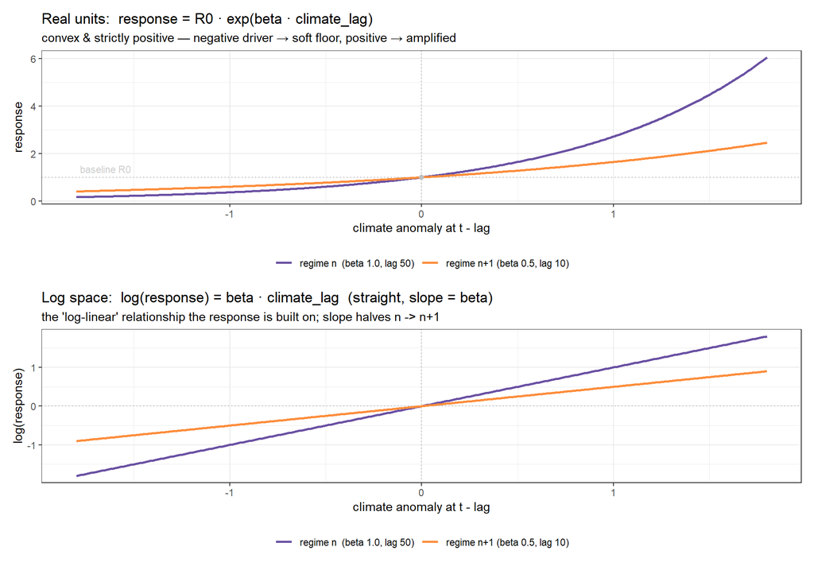

Static climate→response transfer function: response = R0·exp(β·climate_lag). Top: real units (convex, positive, amplifies large positive driver excursions). Bottom: log space (straight line, slope = β). Noise omitted; the actual response adds multiplicative log-space noise and the lag.

```r
suppressMessages(library(patchwork))

# static transfer curve for each regime's sensitivity β (noise-free, lag folded in via climate_lag)
lab_n  <- sprintf("regime n  (beta %.1f, lag %d)",  beta_n, lag_n)
lab_p  <- sprintf("regime n+1 (beta %.1f, lag %d)", beta_p, lag_p)
tf <- expand.grid(x = seq(-1.8, 1.8, length.out = 400), beta = c(beta_n, beta_p))
tf$regime   <- factor(ifelse(tf$beta == beta_n, lab_n, lab_p), levels = c(lab_n, lab_p))
tf$response <- R0 * exp(tf$beta * tf$x)          # real units
tf$logresp  <- log(R0) + tf$beta * tf$x          # log space (straight, slope β)
tf_col <- setNames(c("#6a51a3", "#fd8d3c"), c(lab_n, lab_p))

base_layers <- list(geom_vline(xintercept = 0, linetype = 3, colour = "grey70"),
                    scale_colour_manual(values = tf_col))

pA <- ggplot(tf, aes(x, response, colour = regime)) +
  geom_hline(yintercept = R0, linetype = 3, colour = "grey70") + base_layers +
  geom_line(linewidth = 0.9) +
  annotate("point", x = 0, y = R0, colour = "grey75", size = 1.8) +
  annotate("text", x = -1.78, y = R0, label = "baseline R0", hjust = 0, vjust = -0.6,
           size = 3, colour = "grey80") +
  labs(title = "Real units:  response = R0 · exp(beta · climate_lag)",
       subtitle = "convex & strictly positive — negative driver → soft floor, positive → amplified",
       x = "climate anomaly at t - lag", y = "response", colour = NULL)

pB <- ggplot(tf, aes(x, logresp, colour = regime)) +
  geom_hline(yintercept = log(R0), linetype = 3, colour = "grey70") + base_layers +
  geom_line(linewidth = 0.9) +
  labs(title = "Log space:  log(response) = beta · climate_lag  (straight, slope = beta)",
       subtitle = "the 'log-linear' relationship the response is built on; slope halves n -> n+1",
       x = "climate anomaly at t - lag", y = "log(response)", colour = NULL)

pA / pB
```

# Shift

Regime n → disturbance → adaptation (params blend n→n+1, additional response noise decays 30%→0) → regime n+1. Settles permanently in the new regime.

```r
N   <- 2 * LEN_REG + LEN_ADAPT          # 4250
t   <- seq_len(N)
td  <- LEN_REG                          # disturbance marker (end of regime n)
a0  <- td + 1; a1 <- td + LEN_ADAPT     # adaptation window [2001, 2250]
climate_ext <- make_climate(N)          # exogenous driver (extended for the lag warm-up)

# morph n → n+1 confined to the adaptation window (blends sensitivity + lag together)
w <- ramp(t, td, a1, 0, 1)

# additional disturbance noise on response: 30% at disturbance → 0 by regime n+1 (log space)
add_sd_r <- (t >= a0 & t <= a1) * dist_sd * ramp(t, a0, a1, 1, 0)

d_shift <- build(t, climate_ext, w, gain_r = 1, add_sd_r = add_sd_r) %>%
  mutate(phase = phase_cat(time, td, a1))   # pre | disturbance (td) | transition (adaptation) | post (regime n+1)
```

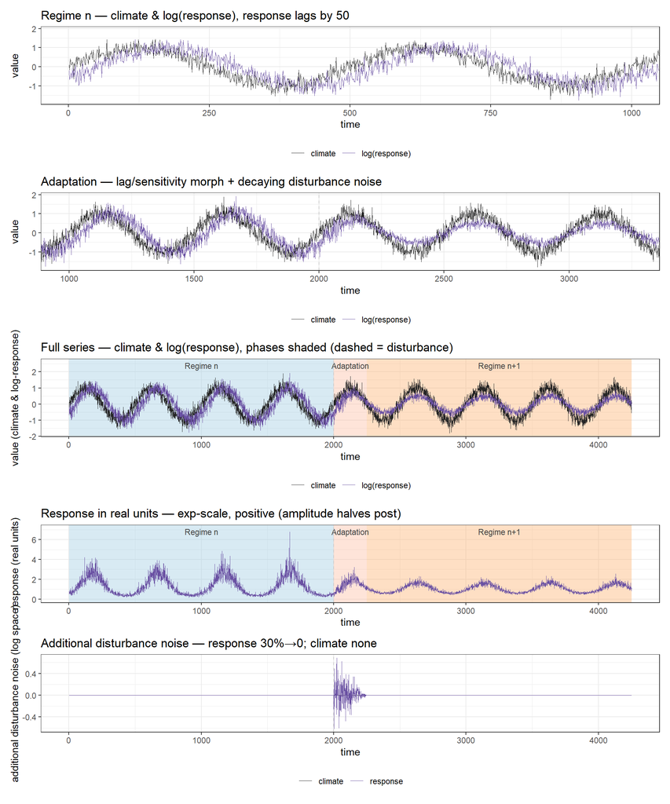

```r
library(patchwork)
ph_shift <- tibble(xmin = c(1, a0, a1 + 1), xmax = c(td, a1, N), type = c("n", "adapt", "np1"),
                   label = c("Regime n", "Adaptation", "Regime n+1"))
plot_series(d_shift, "Regime n — climate & log(response), response lags by 50", xlim = c(1, 2 * P)) /
plot_series(d_shift, "Adaptation — lag/sensitivity morph + decaying disturbance noise",
            xlim = c(td - 2 * P, a1 + 2 * P), vlines = td) /
plot_full(d_shift, ph_shift, "Full series — climate & log(response), phases shaded (dashed = disturbance)", vlines = td) /
plot_real(d_shift, ph_shift, "Response in real units — exp-scale, positive (amplitude halves post)", vlines = td) /
plot_addnoise(d_shift, "Additional disturbance noise — response 30%→0; climate none", vlines = td)
```

```r
write_csv(d_shift %>% transmute(time, climate = round(climate, 6), response = round(response, 6), phase),
          file.path(OUT_DIR, "synthetic_shift.csv"))
```

# Desync

Regime n → disturbance → the **response** decouples: its log-signal gain decays 1→0 while the additional (log-space) disturbance noise grows, so the terminal response is **lognormal noise** whose **log-mean and log-variance** match regime n. The match is **log-space only**: regime n is `exp(sinusoid)` (a Bessel-`I₀` distribution) while the terminal block is `exp(Gaussian)` (lognormal), so at equal log-variance their **raw-unit variance still differs — terminal ≈ +40%** here. Compare in log space. Climate keeps oscillating (constant 25% noise) — a persistent driver the response no longer tracks coherently.

```r
N   <- 2 * LEN_REG + LEN_ADAPT          # 4250
t   <- seq_len(N)
td  <- LEN_REG
a1  <- td + LEN_ADAPT                    # transition [2001, 2250]
climate_ext <- make_climate(N)          # exogenous driver (extended for the lag warm-up)

# terminal LOG-RESPONSE moments to match, estimated from climate_ext's pre-region BEFORE
# building the response (add_* are inputs to build(), so deriving them from its output is
# circular). Regime-n log-signal = beta_n·climate(t−lag_n); add base noise in quadrature.
# NB sd_lr ≈ beta_n·sd(clag): the marginal spread of the regime-n log-signal.
logsig_pre <- beta_n * clag(climate_ext, seq_len(td), lag_n)
mu_lr <- mean(logsig_pre); sd_lr <- sqrt(var(logsig_pre) + base_sd^2)

gain_r   <- ramp(t, td, a1, 1, 0)                              # log-signal fades, 0 after
# additional (log-space) noise grows so terminal log-response marginal-spread-matches regime n
add_sd_r <- ramp(t, td, a1, 0, sqrt(sd_lr^2 - base_sd^2))
add_mu_r <- ramp(t, td, a1, 0, mu_lr)                          # drift to regime-n log-response mean (≈0)

# climate untouched: clean sine + constant 25% noise; only response decouples into noise.
# w = 0 throughout (no morph); decoupling is carried entirely by the fading gain_r. Terminal
# response is lognormal noise whose LOG-moments match regime n. NB match is log-space ONLY:
# regime n is exp(sinusoid) (Bessel I0), terminal is exp(Gaussian) (lognormal), so raw-unit
# variance still differs (terminal ~+40%) at equal log-variance — see desync-check.
d_desync <- build(t, climate_ext, 0, gain_r = gain_r, add_sd_r = add_sd_r, add_mu_r = add_mu_r) %>%
  mutate(phase = phase_cat(time, td, a1))   # pre | disturbance (td) | transition (decoupling) | post (regime n+1 noise)
```

```r
# design goal: terminal LOG-RESPONSE moments ≈ regime n log-response moments.
# NB by-construction identity — add_sd_r/add_mu_r were *set* from mu_lr/sd_lr, so this
# confirms the wiring reproduces them, it is NOT an independent validation of the design.
# Linear-space row shown for contrast: it does NOT match (sd_term ≈ 1.2× sd_reg_n) — regime n
# is exp(sinusoid), terminal is exp(Gaussian); equal log-variance ≠ equal raw variance.
term <- d_desync %>% filter(time > a1)
tibble(space      = c("log", "linear"),
       mean_reg_n = c(mu_lr,           mean(exp(logsig_pre) * R0)),
       mean_term  = c(mean(log(term$response)), mean(term$response)),
       sd_reg_n   = c(sd_lr,           sd(R0 * exp(beta_n * clag(climate_ext, seq_len(td), lag_n) +
                                                   rnorm(td, 0, base_sd)))),
       sd_term    = c(sd(log(term$response)),   sd(term$response)))
```

```
## # A tibble: 2 × 5
##   space  mean_reg_n mean_term sd_reg_n sd_term
##   <chr>       <dbl>     <dbl>    <dbl>   <dbl>
## 1 log      -0.00648  -0.00359    0.753   0.752
## 2 linear    1.30      1.32       0.939   1.13
```

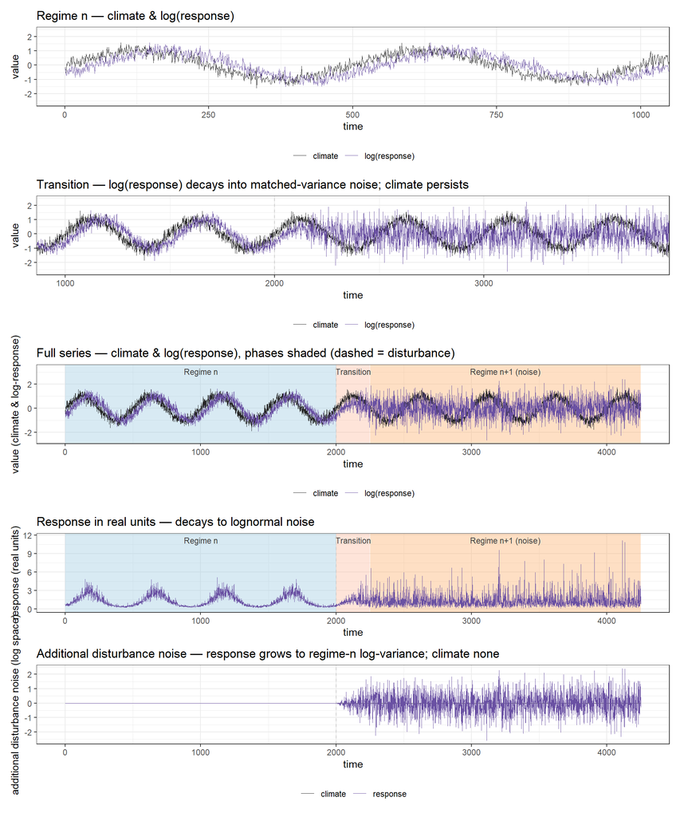

```r
ph_desync <- tibble(xmin = c(1, td + 1, a1 + 1), xmax = c(td, a1, N), type = c("n", "adapt", "np1"),
                    label = c("Regime n", "Transition", "Regime n+1 (noise)"))
plot_series(d_desync, "Regime n — climate & log(response)", xlim = c(1, 2 * P)) /
plot_series(d_desync, "Transition — log(response) decays into matched-variance noise; climate persists",
            xlim = c(td - 2 * P, a1 + 3 * P), vlines = td) /
plot_full(d_desync, ph_desync, "Full series — climate & log(response), phases shaded (dashed = disturbance)", vlines = td) /
plot_real(d_desync, ph_desync, "Response in real units — decays to lognormal noise", vlines = td) /
plot_addnoise(d_desync, "Additional disturbance noise — response grows to regime-n log-variance; climate none", vlines = td)
```

```r
write_csv(d_desync %>% transmute(time, climate = round(climate, 6), response = round(response, 6), phase),
          file.path(OUT_DIR, "synthetic_desync.csv"))
```

# Return

Regime n → disturbance → the response **degrades into noise** (signal gain dips 1→0 while additional log-space noise grows to regime-n matched variance, so at `pk = 2250` the response is momentarily pure noise, decoupled from climate) → then **recovers back to regime n** by `e1 = 2500`. A transient version of Desync: `w = 0` throughout (no parameter morph; regime n+1 is never involved). Both ends are regime n.

```r
N   <- 2 * LEN_REG + 2 * LEN_ADAPT      # 4500
t   <- seq_len(N)
td  <- LEN_REG                          # disturbance
pk  <- td + LEN_ADAPT                   # 2250 max decoupling (signal fully faded to noise)
e1  <- td + 2 * LEN_ADAPT               # 2500 recovered to regime n
climate_ext <- make_climate(N)          # exogenous driver (extended for the lag warm-up)

# transient version of Desync: regime-n log-moments to match at the trough, estimated from
# climate_ext BEFORE build (add_* are build() inputs, so deriving from its output is circular).
logsig_pre <- beta_n * clag(climate_ext, seq_len(td), lag_n)
mu_lr <- mean(logsig_pre); sd_lr <- sqrt(var(logsig_pre) + base_sd^2)

dip      <- tri(t, td, pk, e1)                    # 0 →1 at pk →0 (decoupling weight)
gain_r   <- 1 - dip                               # signal gain: 1 →0 at pk →1
add_sd_r <- dip * sqrt(sd_lr^2 - base_sd^2)       # log-space noise: 0 →full →0
add_mu_r <- dip * mu_lr                           # drift to regime-n log-mean at trough (≈0)

# w = 0 throughout: NO parameter morph, regime n+1 never involved. Decoupling is carried
# entirely by the signal gain dipping to 0 (response = matched-variance noise at pk) and back.
d_return <- build(t, climate_ext, 0, gain_r = gain_r, add_sd_r = add_sd_r, add_mu_r = add_mu_r) %>%
  mutate(phase = phase_cat(time, td, e1))   # pre | disturbance (td) | transition (degrade→noise→return) | post (regime n)
```

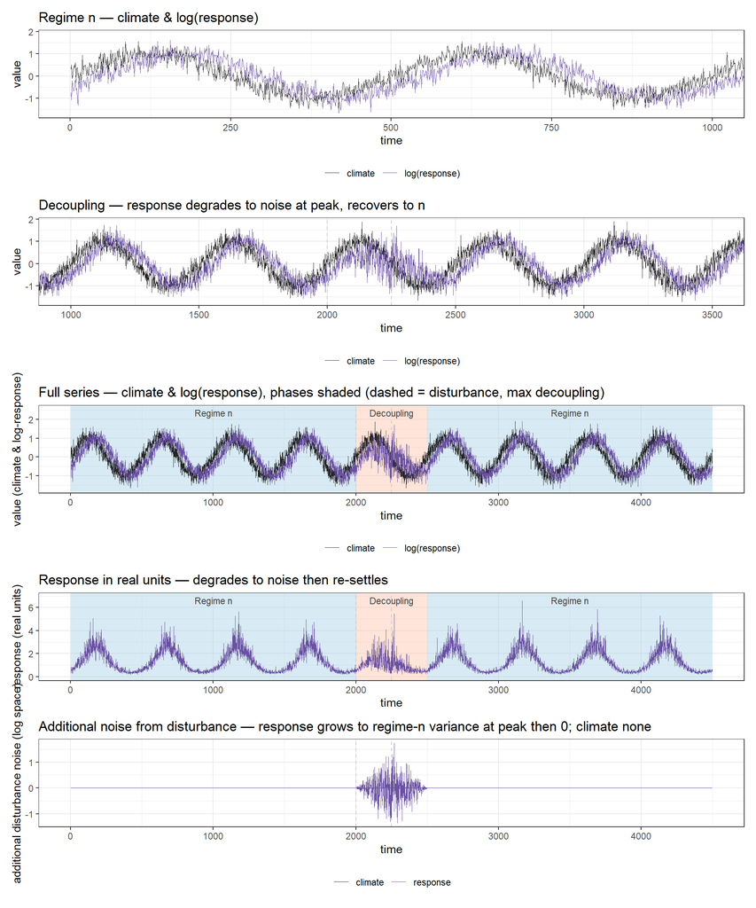

```r
# response degrades into matched-variance noise at pk then recovers; regime n at both ends (w=0)
ph_return <- tibble(xmin = c(1, td + 1, e1 + 1), xmax = c(td, e1, N), type = c("n", "adapt", "n"),
                    label = c("Regime n", "Decoupling", "Regime n"))
plot_series(d_return, "Regime n — climate & log(response)", xlim = c(1, 2 * P)) /
plot_series(d_return, "Decoupling — response degrades to noise at peak, recovers to n",
            xlim = c(td - 2 * P, e1 + 2 * P), vlines = c(td, pk)) /
plot_full(d_return, ph_return, "Full series — climate & log(response), phases shaded (dashed = disturbance, max decoupling)", vlines = c(td, pk)) /
plot_real(d_return, ph_return, "Response in real units — degrades to noise then re-settles", vlines = c(td, pk)) /
plot_addnoise(d_return, "Additional noise from disturbance — response grows to regime-n variance at peak then 0; climate none", vlines = c(td, pk))
```

```r
write_csv(d_return %>% transmute(time, climate = round(climate, 6), response = round(response, 6), phase),
          file.path(OUT_DIR, "synthetic_return.csv"))
```